# Simple Linear Regression

Agbugah Raymond

2025-04-23

Data on Roller Weight

| weight | depression |
| --- | --- |
| 1.9 | 2 |
| 3.1 | 1 |
| 3.3 | 5 |
| 4.8 | 5 |
| 5.3 | 20 |
| 6.1 | 20 |
| 6.4 | 23 |
| 7.6 | 10 |
| 9.8 | 30 |
| 12.4 | 25 |

```
## 'data.frame':    10 obs. of  2 variables:
##  $ weight    : num  1.9 3.1 3.3 4.8 5.3 6.1 6.4 7.6 9.8 12.4
##  $ depression: num  2 1 5 5 20 20 23 10 30 25
```

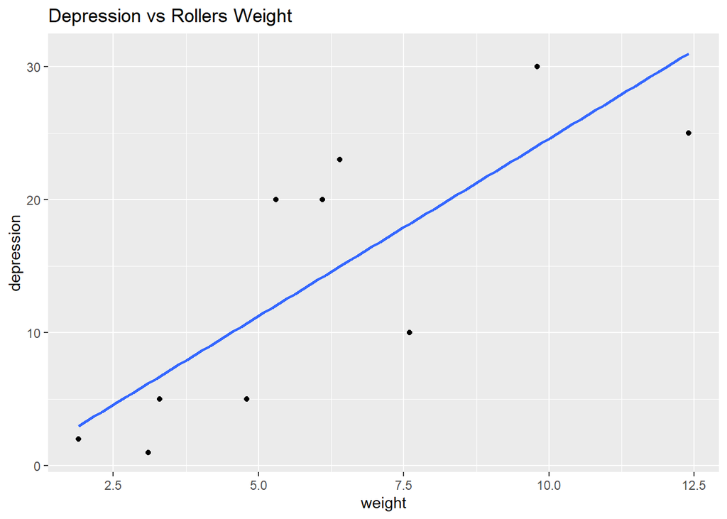

From the graph, you observe a linear pattern with some variability around it. Note, intercept is the predicted value of dependent variables when x = 0, it is more useful when x takes value close to zero.

```
##
## Call:
## lm(formula = depression ~ weight, data = roller)
##
## Residuals:
##    Min     1Q Median     3Q    Max
## -8.180 -5.580 -1.346  5.920  8.020
##
## Coefficients:
##             Estimate Std. Error t value Pr(>|t|)
## (Intercept)  -2.0871     4.7543  -0.439  0.67227
## weight        2.6667     0.7002   3.808  0.00518 **
## ---
## Signif. codes:  0 '***' 0.001 '**' 0.01 '*' 0.05 '.' 0.1 ' ' 1
##
## Residual standard error: 6.735 on 8 degrees of freedom
## Multiple R-squared:  0.6445, Adjusted R-squared:  0.6001
## F-statistic:  14.5 on 1 and 8 DF,  p-value: 0.005175
```

1. Linear Model is
2. Y = B0 +B1X +e 1.where e is the error therefore, the model above is given as
3. Y = -2.0871 +2.6667weight

The standard error and t-value are summarizing the probability value. t-values are gotten by dividing the estimates with the standard error. In this estimate,8 degrees of freedom is been considered because we are estimating two parameters. when roller weight is 0, on an average the depression will be -2.0871.

depression= -2.0871+2.6667*weight.

Slope is the average change in y when x increases by 1 unit. where slope is 2.6667. For every 1 unit increase in roller weight, on an average, depression on grass increases by 2.6667.

Predicting y beyond the range of x is not advisable due to lack of evidence that the relationship between x and y will be linear and this is because regression model is used for estimation and not for prediction.

# **Hypothesis Testing**

Ho: Weight is not statistically significant H1: Weight is statistically significant

confidence interval = 0.05 Since the p-value which is 0.00518 is less than 0.05,we accept the alternate hypothesis and conclude that weight is statistically significant. Which means that weight contributes to this model significantly.